# The case for more GIS in front-line diplomacy

|| **0.0|READ ME** || 1.0|EXTRACT || 2.0|TRANSFORM || 3.0|LOAD and ANALYSE ||

### 0.0 Read me

> **Purpose of section**: brief outline of document, its content and pre-requisits  
> **Inputs**: none  
> **Outputs**: none

#### 0.1 Outline of document

This notebook outlines the *process* and *code* outputs associated with a project on the role of GIS in international relations and diplomacy academia and practice.

**Final submission** and analysis can be found here `13.01.2020`

#### 0.2 Document index

0. Read me
   - || 0.1-Outline || 0.2-Index || 0.3-Setup ||
1. Extract
   - || 1.1-Load || 1.2-Tidy || 1.3-Summarise ||
2. Transform
   - || 2.1-Reload data || 2.2-ISO encoding || 2.3-Geocoding ||
3. Load and analyse
   - || 3.1-Load and segment data frame || 3.2-Define visualisation function || 3.3-Visualise 1.0 || 3.4-Visualise 2.0, clustering and outlier removal ||
- Reference code section

##### Process overview image

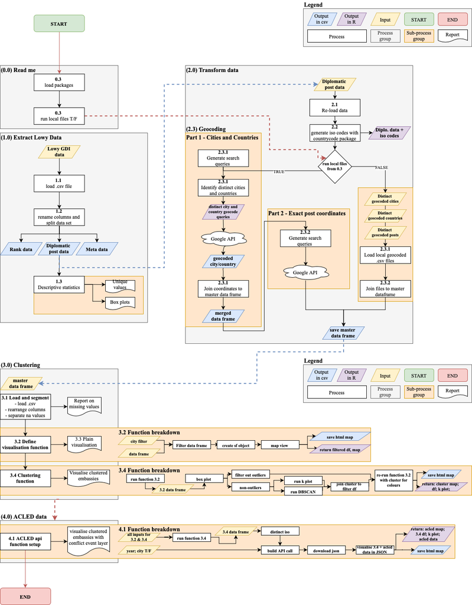

#### 0.3 Pre-requisites and set up

In order for the code below to work, please ensure you have installed and loaded the relevant packages.

```r
#Installing packages (uncomment as required)
#install.packages(c("countrycode","tidyverse","sf","mapview","ggmap"))

library(countrycode) #iso tagging of countries
library(tidyverse) #number of packages for data manipulation, specifically want readr, dplyr, tibble
library(sf) #creation of spatial objects
library(mapview) #mapping package
library(ggmap) #for google api access
library(RCurl) #to download ACLED content
library(jsonlite) #to process ACLED downloaded info
```

Set parameters for the entire workflow

```r
#Set this to TRUE or FALSE to determine whether to use local, pre-loaded files or refresh via relevant API, i.e. (Google/ACLED) connections.
use_local_files <- TRUE
```

|| 0.0|READ ME || **1.0|EXTRACT** || 2.0|TRANSFORM || 3.0|LOAD and ANALYSE ||

### 1.0 Extract Lowy Institute data

> **Purpose of section**:  
> **Inputs**: Local Lowy Institute dataset available [here](https://globaldiplomacyindex.lowyinstitute.org/about.html#)  
> **Outputs**: Renamed and separated .csv filess

**Note** on downloading from the Lowy Institute site, there may be incompatibility with downloads in Safari, chrome is recommended, have not tested other browsers.

#### 1.1 Load .csv file and check data types

Back to index

```r
###Confirm working directory
print(getwd())
###open latest csv document based on relative path
lowy_raw_data <- read.csv("./Data/Raw_data/2019_LowyInstituteGlobalDiplomacyIndex_FullDataset.csv")
```

#### 1.2 Tidy up dataset

Back to index **Check for**: factors; rename columns; seperate out relevant columns  
**Output**:

1. renamed data frame `lowy_renamed`
2. other meta data `lowy_meta`
3. ranking data `lowy_rank`
4. **posting data** `lowy_posting` **<===** this is the relevant one for the rest of the work

```r
###check for factor columns and change them to character columns
#more of a pre-emptive measure
i <- sapply(lowy_raw_data, is.factor)
lowy_raw_data[i] <- lapply(lowy_raw_data[i], as.character)

###column rename
#new data frame (a)
lowy_renamed <- lowy_raw_data

#rename columns
lowy_renamed <- lowy_renamed %>% dplyr::rename(
  send_country=COUNTRY,
  #metadata
  meta_gdp_usd_billions = GDP..B..USD.,
  meta_population_millions = POPULATION..M.,
  #ranking columns
  rank_g20 = G20.RANK,
  rank_OECD = OECD.RANK,
  rank_asia = ASIA.RANK,
  rank_overall = OVERALL.RANK,
  #post country info
  post_city = POST.CITY,
  post_country = POST.COUNTRY,
  post_type = TYPE.OF.POST,
  post_title = POST.TYPE.TITLE
  )

#data frame with all metadata (GDP and population) (b)
lowy_meta <- lowy_renamed[, c("send_country","meta_population_millions","meta_gdp_usd_billions")]

#data frame with all rankings (G20, OECD, Asia and overall) (c)
lowy_rank <- lowy_renamed[,c("send_country","rank_g20","rank_OECD","rank_asia","rank_overall")]

#data frame with information on sending country, post city, country as well as post type and title (d)
lowy_posting <- lowy_renamed[,c("send_country","post_city","post_country","post_type","post_title")]

###save data frames as .csv files ready for part 2
write.csv(lowy_posting,"./Data/Processing/Part_1_Out_Lowy_Posting.csv", row.names = FALSE)
write.csv(lowy_rank,"./Data/Processing/Part_1_Out_Lowy_Rank.csv", row.names = FALSE)
write.csv(lowy_meta,"./Data/Processing/Part_1_Out_Lowy_Meta.csv", row.names = FALSE)

#quick preview of data frame to work on
head(lowy_posting,2)
```

|  | send_country | post_city | post_country | post_type | post_title |
| --- | --- | --- | --- | --- | --- |
| 1 | Argentina | Algiers | Algeria | Embassy / High Commission | Embassy |
| 2 | Argentina | Luanda | Angola | Embassy / High Commission | Embassy |

#### 1.3 Raw key information

Back to index Warning: an error may appear when running

```r
###report all unique values/entries
#Summarise all unique values in crude print out
for(column in colnames(lowy_posting)){
  cat(column,"has",length(apply(lowy_posting[column],2,unique)),"unique values\n")
}
```

```
send_country has 61 unique values
post_city has 686 unique values
post_country has 207 unique values
post_type has 4 unique values
post_title has 141 unique values
```

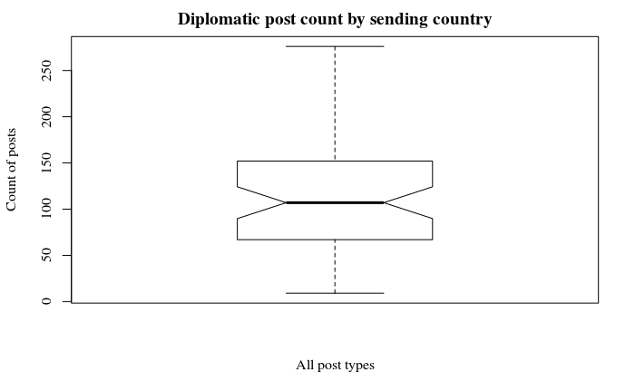

```r
###summary stats
lowy_type_table <- ftable(table(lowy_posting$send_country,lowy_posting$post_type))

###summarise count by send country
lowy_count_per_send_country <- lowy_posting %>%
  group_by(send_country) %>%
  summarise(count = n()) %>%
  arrange(desc(count))

per_country_count <- lowy_count_per_send_country$count
par(family = "Times New Roman")
per_country_box <- boxplot(data=per_country_count, x=per_country_count, main="Diplomatic post count by sending country",
   xlab="All post types", ylab="Count of posts",notch = TRUE)
```

```r
cat("Per country count summary",
    "\nMin value:",per_country_box$stats[1,1],
    "\n25th percentile:",per_country_box$stats[2,1],
    "\nMedian value:",per_country_box$stats[3,1],
    "\n75th percentile:",per_country_box$stats[4,1],
    "\nMax value:",per_country_box$stats[5,1]
    )
```

```
Per country count summary
Min value: 9
25th percentile: 67
Median value: 107
75th percentile: 152
Max value: 276
```

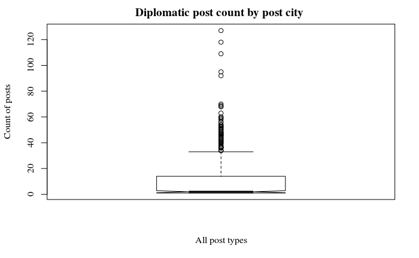

```r
###summarise count by post city
lowy_count_per_post_city <- lowy_posting %>%
  group_by(post_city) %>%
  summarise(count = n()) %>%
  arrange(desc(count))

per_post_city_count <- lowy_count_per_post_city$count

per_post_city_box <- boxplot(data=per_post_city_count, x=per_post_city_count, main="Diplomatic post count by post city ",
   xlab="All post types", ylab="Count of posts",notch = TRUE)
```

```r
cat("Per post city count summary",
    "\nMin value:",per_post_city_box$stats[1,1],
    "\n25th percentile:",per_post_city_box$stats[2,1],
    "\nMedian value:",per_post_city_box$stats[3,1],
    "\n75th percentile:",per_post_city_box$stats[4,1],
    "\nMax value:",per_post_city_box$stats[5,1]
    )
```

[output not shown]

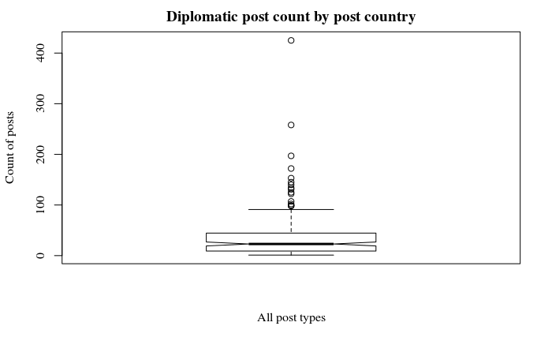

```r
###summarise count by post country
lowy_count_per_post_country <- lowy_posting %>%
  group_by(post_country) %>%
  summarise(count = n()) %>%
  arrange(desc(count))

per_post_country_count <- lowy_count_per_post_country$count

per_post_country_box <- boxplot(data=per_post_country_count, x=per_post_country_count, main="Diplomatic post count by post country",
   xlab="All post types", ylab="Count of posts",notch = TRUE)
```

```r
cat("Per post country count summary",
    "\nMin value:",per_post_country_box$stats[1,1],
    "\n25th percentile:",per_post_country_box$stats[2,1],
    "\nMedian value:",per_post_country_box$stats[3,1],
    "\n75th percentile:",per_post_country_box$stats[4,1],
    "\nMax value:",per_post_country_box$stats[5,1]
    )
```

[output not shown]

|| 0.0|READ ME || 1.0|EXTRACT || **2.0|TRANSFORM** || 3.0|LOAD and ANALYSE ||

### 2.0 Transform Lowy Institute data

#### 2.1 Re-load

Back to index

```r
lowy_data <- read_csv("./Data/Processing/Part_1_Out_Lowy_Posting.csv")
```

```r
#lowy_data <- head(lowy_data,5) #FOR SAMPLE WORK
```

#### 2.2 ISO codes

Back to index

```r
###Set up

#iso dataframe
lowy_data_iso <- lowy_data

#country_iso list [column 1]
iso_list_send_country <- c()
iso_list_send_country_num <- c()
#post_country_iso list [column 3]
iso_list_post_country <- c()
iso_list_post_country_num <- c()

###ending country column (1) three digit numbers
for(country in lowy_data_iso[1]){
  country_iso <- countrycode(
    #call the entry of 'Country' for the row_number currently being taken by for loop
    sourcevar = country,
    #three letter iso code
    destination = "iso3n",
    #based on english language names
    origin = "country.name")

  #add value to a list
  iso_list_send_country_num <- append(iso_list_send_country_num,country_iso)
}

###sending country column (1) three digit letters
for(country in lowy_data_iso[1]){
  country_iso <- countrycode(
    #call the entry of 'Country' for the row_number currently being taken by for loop
    sourcevar = country,
    #three letter iso code
    destination = "genc3c",
    #based on english language names
    origin = "country.name")

  #add value to a list
  iso_list_send_country <- append(iso_list_send_country,country_iso)
}
#===================================
###Post country column (3) three digit numbers
for(country in lowy_data_iso[3]){
  post_country_iso <- countrycode(
    #call the entry of 'Country' for the row_number currently being taken by for loop
    sourcevar = country,
    #three letter iso code
    destination = "iso3n",
    #based on english language names
    origin = "country.name")

  #add value to a list
  iso_list_post_country_num <- append(iso_list_post_country_num,post_country_iso)
}
```

```
Some values were not matched unambiguously: Abkhazia*, Cura�ao, Jerusalem*, Kosovo*, South Ossetia*
```

```r
###Post country column (3) three letters
for(country in lowy_data_iso[3]){
  post_country_iso <- countrycode(
    #call the entry of 'Country' for the row_number currently being taken by for loop
    sourcevar = country,
    #three letter iso code
    destination = "genc3c",
    #based on english language names
    origin = "country.name")

  #add value to a list
  iso_list_post_country <- append(iso_list_post_country,post_country_iso)
}
```

```
Some values were not matched unambiguously: Abkhazia*, Cura�ao, Jerusalem*, South Ossetia*
```

```r
###create new columns
lowy_data_iso$send_country_iso = iso_list_send_country
lowy_data_iso$send_country_iso_num = iso_list_send_country_num

lowy_data_iso$post_country_iso = iso_list_post_country
lowy_data_iso$post_country_iso_num = iso_list_post_country_num

###preview data frame
head(lowy_data_iso,3)
```

| send_country | post_city | post_country | post_type | post_title | send_country_iso | send_country_iso_num | post_country_iso | post_country_iso_num |
| --- | --- | --- | --- | --- | --- | --- | --- | --- |
| Argentina | Algiers | Algeria | Embassy / High Commission | Embassy | ARG | 32 | DZA | 12 |
| Argentina | Luanda | Angola | Embassy / High Commission | Embassy | ARG | 32 | AGO | 24 |
| Argentina | Yerevan | Armenia | Embassy / High Commission | Embassy | ARG | 32 | ARM | 51 |

#### 2.3 Geo-coding

Back to index This section requires a google api key; you can set one up [here](https://console.cloud.google.com/) through the google cloud platform

```r
register_google(key = "AIzaSyDNlUg_mclZ4kSJMDvbj_UVMHds8vkz2nE")
```

Code to run the geocoding for each country column (`send_country` `post_country`), city `post_city` + `post country` (to avoid finding wrong city)

**Part 1 cities and countries** Back to index

```r
###========Preparation

###concatenate post city and post country columns
lowy_data_iso$post_city_country = paste(
  lowy_data_iso$post_city,
  lowy_data_iso$post_country,
  sep=", ")

###geo-c - concatenated city and country names
geo_city_country <- distinct(lowy_data_iso,post_city_country)
geo_city_country_df <- as.data.frame(geo_city_country)

###geo-code - sending countries
geo_send_country <- distinct(lowy_data_iso,send_country)
geo_send_country_df <- as.data.frame(geo_send_country)

###========POST CITIES
#if local file tag is set to TRUE, google api will not be used
if(use_local_files) {
  print("Local file flag set to TRUE, using local files")
  geo_city_country_df_dl <- read.csv("./Data/GoogleAPI/Geo_City_Country_DL.csv")
} else {
  print("Local file flag set to FALSE, calling google now!")
  geo_city_country_df_dl <- mutate_geocode(geo_city_country_df, post_city_country)
  #Save .csv file
  write.csv(geo_city_country_df_dl,"./Data/GoogleAPI/Geo_City_Country_DL.csv", row.names = FALSE)
}
```

```
[1] "Local file flag set to TRUE, using local files"
```

```r
###========SEND COUNTRIES
#if local file tag is set to TRUE, google api will not be used
if(use_local_files) {
  print("Local file flag set to TRUE, using local files")
  geo_send_country_df_dl <- read.csv("./Data/GoogleAPI/Geo_Send_Country_DL.csv")
} else {
  print("Local file flag set to FALSE, calling google now!")
  geo_send_country_df_dl <- mutate_geocode(geo_send_country_df, send_country)
  #Save .csv file
  write.csv(geo_send_country_df_dl,"./Data/GoogleAPI/Geo_Send_Country_DL.csv", row.names = FALSE)
}
```

```
[1] "Local file flag set to TRUE, using local files"
```

```r
###========VIEW DATAFRAMES
head(geo_city_country_df_dl,3)
```

|  | post_city_country | lon | lat |
| --- | --- | --- | --- |
| 1 | Algiers, Algeria | 3.058756 | 36.753768 |
| 2 | Luanda, Angola | 13.230176 | -8.814656 |
| 3 | Yerevan, Armenia | 44.515209 | 40.187202 |

```r
head(geo_send_country_df_dl,3)
```

|  | send_country | lon | lat |
| --- | --- | --- | --- |
| 1 | Argentina | -63.61667 | -38.41610 |
| 2 | Australia | 133.77514 | -25.27440 |
| 3 | Austria | 14.55007 | 47.51623 |

```r
###========JOIN DATA TO MASTER DATA FRAME
lowy_data_geo <- lowy_data_iso

#Join send lon/lat
lowy_data_geo <- merge(lowy_data_geo,geo_send_country_df_dl, by = "send_country")

lowy_data_geo <- lowy_data_geo %>% rename(
  send_lon =lon,
  send_lat = lat)

head(lowy_data_geo)
```

|  | send_country | post_city | post_country | post_type | post_title | send_country_iso | send_country_iso_num | post_country_iso | post_country_iso_num | post_city_country | send_lon | send_lat |
| --- | --- | --- | --- | --- | --- | --- | --- | --- | --- | --- | --- | --- |
| 1 | Argentina | Algiers | Algeria | Embassy / High Commission | Embassy | ARG | 32 | DZA | 12 | Algiers, Algeria | -63.61667 | -38.4161 |
| 2 | Argentina | Luanda | Angola | Embassy / High Commission | Embassy | ARG | 32 | AGO | 24 | Luanda, Angola | -63.61667 | -38.4161 |
| 3 | Argentina | Yerevan | Armenia | Embassy / High Commission | Embassy | ARG | 32 | ARM | 51 | Yerevan, Armenia | -63.61667 | -38.4161 |
| 4 | Argentina | Canberra | Australia | Embassy / High Commission | Embassy | ARG | 32 | AUS | 36 | Canberra, Australia | -63.61667 | -38.4161 |
| 5 | Argentina | Vienna | Austria | Embassy / High Commission | Embassy | ARG | 32 | AUT | 40 | Vienna, Austria | -63.61667 | -38.4161 |
| 6 | Argentina | Baku | Azerbaijan | Embassy / High Commission | Embassy | ARG | 32 | AZE | 31 | Baku, Azerbaijan | -63.61667 | -38.4161 |

```r
#Join post city lon/lat
lowy_data_geo <- merge(lowy_data_geo,geo_city_country_df_dl, by = "post_city_country")

lowy_data_geo <- lowy_data_geo %>% rename(
  post_city_lon =lon,
  post_city_lat = lat)

head(lowy_data_geo,3)
```

|  | post_city_country | send_country | post_city | post_country | post_type | post_title | send_country_iso | send_country_iso_num | post_country_iso | post_country_iso_num | send_lon | send_lat | post_city_lon | post_city_lat |
| --- | --- | --- | --- | --- | --- | --- | --- | --- | --- | --- | --- | --- | --- | --- |
| 1 | Abidjan, Cote d'Ivoire | Israel | Abidjan | Cote d'Ivoire | Embassy / High Commission | Embassy | ISR | 376 | CIV | 384 | 34.851612 | 31.04605 | -4.008256 | 5.359952 |
| 2 | Abidjan, Cote d'Ivoire | United Kingdom | Abidjan | Cote d'Ivoire | Embassy / High Commission | Embassy | GBR | 826 | CIV | 384 | -3.435973 | 55.37805 | -4.008256 | 5.359952 |
| 3 | Abidjan, Cote d'Ivoire | Japan | Abidjan | Cote d'Ivoire | Embassy / High Commission | Embassy | JPN | 392 | CIV | 384 | 138.252924 | 36.20482 | -4.008256 | 5.359952 |

**Part 2 exact embassy locations**  
Back to index  
Code to run the geocoding for exact embassy locations. Using combination of `send_country`+`post_country`+“Embassy”+ `post_city`

```r
###master dataframe with all data
lowy_data_geo_master <- lowy_data_geo

###Exact geocoding query
lowy_data_geo_master$full_geo_query = paste(
  lowy_data_geo_master$send_country,
  lowy_data_geo_master$post_title,
  lowy_data_geo_master$post_city_country,
  sep=", ")

###RUN GEOCODING
if(use_local_files) {
  print("Local file flag set to TRUE, using local files")
  lowy_data_geo_master <- read.csv("./Data/GoogleAPI/lowy_data_geo_master.csv")
} else {
  print("Local file flag set to FALSE, calling google now!")
  lowy_data_geo_master <- mutate_geocode(lowy_data_geo_master, full_geo_query)

  #rename columns
  lowy_data_geo_master <- lowy_data_geo_master %>% rename(
  exact_post_lon = lon,
  exact_post_lat = lat)

  #Save .csv file
  write.csv(lowy_data_geo_master,"./Data/GoogleAPI/lowy_data_geo_master.csv", row.names = FALSE)
}
```

```
[1] "Local file flag set to TRUE, using local files"
```

```r
#Unload unnecessary data from global environment
rm(list = ls()) #purge all else (comment/uncomment as needed)
```

|| 0.0|READ ME || 1.0|EXTRACT || 2.0|TRANSFORM || **3.0|LOAD and ANALYSE** ||

### 3.0 Load and analyse Lowy Institute data

> **Purpose of section**: visualise coordinates; and run clustering analysis  
> **Inputs**: `lowy_data_geo_master` (final output of part 2)  
> **Outputs**: maps and visuals

#### 3.1 Load data and segmet usable part for analysis

Back to index

```r
###Load data from section 2
lowy_data_complete <- read_csv("./Data/GoogleAPI/lowy_data_geo_master.csv")
```

```r
###Filter out unusable datapoints
#names(lowy_data_complete)

#Re-arrange columns and sort table
lowy_data_complete <-lowy_data_complete
lowy_data_complete = select(lowy_data_complete,
                            #sending data
                            send_country_iso,
                            send_country,
                            send_lon,
                            send_lat,
                            #posting data
                            post_country_iso,
                            post_country,
                            post_city_country,
                            post_city,
                            post_city_lon,
                            post_city_lat,
                            post_type,
                            post_title,
                            #other columns
                            everything())

lowy_data_complete <- lowy_data_complete[order(lowy_data_complete$send_country),]
#head(lowy_data_complete)

#Filter out NA values (around 44 values)
geo_lowy_NA_values <- lowy_data_complete %>%
  dplyr::select(everything()) %>%
  dplyr::filter(is.na(exact_post_lon))

geo_lowy_no_NA <- lowy_data_complete %>%
  dplyr::select(everything()) %>%
  dplyr::filter(!is.na(exact_post_lon))
```

```r
#Preview table
report_full_length <-length(lowy_data_complete$send_country)
report_na_length <- length(geo_lowy_NA_values$send_country)
report_non_na_length <- length(geo_lowy_no_NA$send_country)

cat("There are,", report_full_length,"entries in the complete data frame.","\nFrom these,",report_na_length,"are NA/blank. (",report_na_length/report_full_length*100,"% )","\nIn total,",report_non_na_length,"entries have valid coordinates.","\nTotal coverage is:",report_non_na_length/report_full_length*100,"%")
```

```
There are, 7317 entries in the complete data frame.
From these, 43 are NA/blank. ( 0.5876725 % )
In total, 7274 entries have valid coordinates.
Total coverage is: 99.41233 %
```

#### 3.2 Geo-coding analysis function

Back to index Function to take in data frame, and a filter to visualise and return filtered dataframe for further analysis `f_exact_city_postings <- function(p_city_filter,p_df){}` see code here for further details

#### 3.3 Visualise

Back to index Run function on array of cities of interest

```r
###run function
f_out <- f_exact_city_postings(p_city_filter = "Tehran",p_df = geo_lowy_no_NA)
f_out$map
```

[interactive chart not shown]

```r
NA
```

#### 3.4 Clustering

Use function output from 3.3 to run DBSCAN spatial clustering analysis

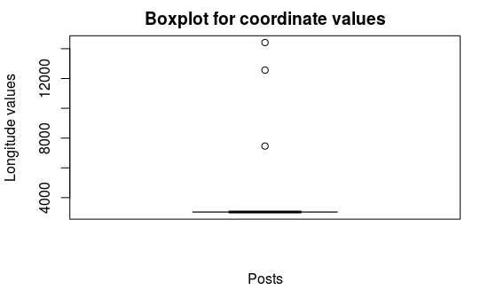

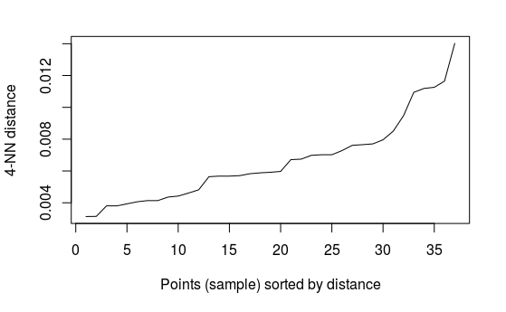

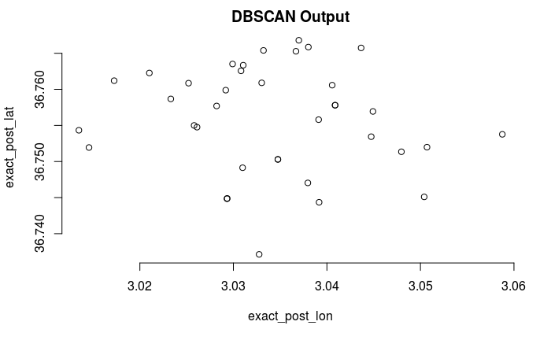

```r
#============== function start
f_exact_city_cluster <- function(p_city_filter,p_df,p_eps,p_k = 4,p_outlier_remove = FALSE){

    #run original function
  f_out <- f_exact_city_postings(p_city_filter = p_city_filter,p_df = p_df)

  f_out$df

  #assign coordinates of filtered dataset to variable
  db_coordinates <- f_out$df[c("exact_post_lon","exact_post_lat")]*1000

  #boxplot
  db_coordinates_box <- boxplot(data=db_coordinates$exact_post_lon, x=db_coordinates$exact_post_lon, main="Boxplot for coordinate values",
   xlab="Posts", ylab="Longitude values",notch = TRUE) #[RETURN 1]

  db_coordinates <- db_coordinates/1000
  db_coordinates_out <- db_coordinates_box$out/1000

  if(length(db_coordinates_out) == 0){
    zero_outliers <- FALSE
  }else{
    zero_outliers <- TRUE
  }

  #negation for filtering
  `%nin%` <- Negate("%in%")


  #if outlier parameter set to true, they will be removed, else can keep going as is
  if(p_outlier_remove & zero_outliers){

    #clustering objects
    db_coordinates_keep <- db_coordinates%>% filter(exact_post_lon %nin% db_coordinates_out)
    db_coordinates_out_cluster <- db_coordinates%>% filter(exact_post_lon %in% db_coordinates_out)

    #full dataframe without outliers
    f_out_df <- f_out$df %>% filter(exact_post_lon %nin% db_coordinates_out)

    #outlier dataframe
    f_out_outlier_df <- f_out$df %>% filter(exact_post_lon %in% db_coordinates_out)

    f_out_outlier_df_sf <- st_as_sf(f_out_outlier_df,
                                      coords=c("exact_post_lon","exact_post_lat"),
                                      crs = 4326,remove = FALSE)
  }else{
    db_coordinates_keep <- db_coordinates
    f_out_df <- f_out$df
  }

  #Indetify optimal eps
  kNNdist_df <- dbscan::kNNdist(db_coordinates_keep, k = p_k)
  db_kNN_plot <- dbscan::kNNdistplot(db_coordinates_keep,k = p_k) #[RETURN 2]

  #now run the dbscan analysis
  db <- fpc::dbscan(db_coordinates_keep, eps = p_eps, MinPts = p_k)

  #now plot the results [RETURN 3]
  db_plot <- plot(db, db_coordinates_keep, main = "DBSCAN Output", frame = F)

  #add 2 to cluster to avoid 0 values as leaflet doesn't like to colour by 0 (zero) values and colour '1' is black
  db_coordinates_keep$cluster <- db$cluster+2
  dbscan_test_df <- db_coordinates_keep

  dbscan_test_df

  f_out_cluster <- f_exact_city_postings(p_city_filter = p_city_filter,p_df = f_out_df,p_colour = dbscan_test_df$cluster)

  if(p_outlier_remove & zero_outliers){
    f_out_cluster_map <- f_out_cluster$map + mapview(f_out_outlier_df_sf,
      legend = FALSE,
      layer.name = "Outliers",
      label = f_out_outlier_df_sf$full_geo_query,
      color = "yellow",
      alpha.regions = 1,
      col.regions = "yellow",
      cex = 4)
  }else{
    #no outliers to plot
    f_out_cluster_map <- f_out_cluster$map #[RETURN]
  }

  f_out_cluster$df #[RETURN]

   mapshot(f_out_cluster_map, url = paste("/cloud/project/R_Notebook/Final/Data/MapFiles/",p_city_filter,"cluster_map.html",sep="_"))

  #return list of relevant elements
  return_list <- list(df_sub = f_out$df,map = f_out$map,box_plot = db_coordinates_box, k_plot = db_kNN_plot,f_cluster_map = f_out_cluster_map, f_cluster_df = f_out_cluster$df)

    return(return_list)

}
#============== function end
#f_exact_city_cluster(p_city_filter = "Tehran",p_df = geo_lowy_no_NA,p_eps = 0.015,p_k =4,p_outlier_remove = TRUE)
#f_exact_city_cluster(p_city_filter = "London",p_df = geo_lowy_no_NA,p_eps = 0.005,p_k =4,p_outlier_remove = TRUE)

#f_exact_city_cluster(p_city_filter = "Manila",p_df = geo_lowy_no_NA,p_eps = 0.003,p_k =4,p_outlier_remove = TRUE)
#f_exact_city_cluster(p_city_filter = "Nairobi",p_df = geo_lowy_no_NA,p_eps = 0.010,p_k =4,p_outlier_remove = TRUE)
#f_exact_city_cluster(p_city_filter = "Singapore",p_df = geo_lowy_no_NA,p_eps = 0.005,p_k =4,p_outlier_remove = TRUE)

sample_anlaysis <- f_exact_city_cluster(p_city_filter = "Algiers",p_df = geo_lowy_no_NA,p_eps = 0.002,p_k =4,p_outlier_remove = TRUE)
```

```r
sample_anlaysis$df_sub
```

| send_country_iso | send_country | send_lon | send_lat | post_country_iso | post_country | post_city_country | post_city | post_city_lon | post_city_lat | post_type | post_title | send_country_iso_num | post_country_iso_num | full_geo_query | exact_post_lon | exact_post_lat |
| --- | --- | --- | --- | --- | --- | --- | --- | --- | --- | --- | --- | --- | --- | --- | --- | --- |
| ARG | Argentina | -63.616672 | -38.416097 | DZA | Algeria | Algiers, Algeria | Algiers | 3.058756 | 36.75377 | Embassy / High Commission | Embassy | 32 | 12 | Argentina, Embassy, Algiers, Algeria | 3.029182 | 36.75989 |
| AUT | Austria | 14.550072 | 47.516231 | DZA | Algeria | Algiers, Algeria | Algiers | 3.058756 | 36.75377 | Embassy / High Commission | Embassy | 40 | 12 | Austria, Embassy, Algiers, Algeria | 3.026115 | 36.75476 |
| BGD | Bangladesh | 90.356331 | 23.684994 | DZA | Algeria | Algiers, Algeria | Algiers | 3.058756 | 36.75377 | Embassy / High Commission | Embassy | 50 | 12 | Bangladesh, Embassy, Algiers, Algeria | 3.031051 | 36.76335 |
| BEL | Belgium | 4.469936 | 50.503887 | DZA | Algeria | Algiers, Algeria | Algiers | 3.058756 | 36.75377 | Embassy / High Commission | Embassy | 56 | 12 | Belgium, Embassy, Algiers, Algeria | 3.033218 | 36.76539 |
| BRA | Brazil | -51.925280 | -14.235004 | DZA | Algeria | Algiers, Algeria | Algiers | 3.058756 | 36.75377 | Embassy / High Commission | Embassy | 76 | 12 | Brazil, Embassy, Algiers, Algeria | 3.033026 | 36.76090 |
| CAN | Canada | -106.346771 | 56.130366 | DZA | Algeria | Algiers, Algeria | Algiers | 3.058756 | 36.75377 | Embassy / High Commission | Embassy | 124 | 12 | Canada, Embassy, Algiers, Algeria | 3.017250 | 36.76120 |
| CHL | Chile | -71.542969 | -35.675147 | DZA | Algeria | Algiers, Algeria | Algiers | 3.058756 | 36.75377 | Embassy / High Commission | Embassy | 152 | 12 | Chile, Embassy, Algiers, Algeria | 3.030987 | 36.74914 |
| CHN | China | 104.195397 | 35.861660 | DZA | Algeria | Algiers, Algeria | Algiers | 3.058756 | 36.75377 | Embassy / High Commission | Embassy | 156 | 12 | China, Embassy, Algiers, Algeria | 3.050702 | 36.75199 |
| CZE | Czech Republic | 15.472962 | 49.817492 | DZA | Algeria | Algiers, Algeria | Algiers | 3.058756 | 36.75377 | Embassy / High Commission | Embassy | 203 | 12 | Czech Republic, Embassy, Algiers, Algeria | 14.411967 | 50.10214 |
| DNK | Denmark | 9.501785 | 56.263920 | DZA | Algeria | Algiers, Algeria | Algiers | 3.058756 | 36.75377 | Embassy / High Commission | Embassy | 208 | 12 | Denmark, Embassy, Algiers, Algeria | 12.561669 | 55.73417 |

[output cut: 30 more lines]

|| 0.0|READ ME || 1.0|EXTRACT || 2.0|TRANSFORM || **3.0|LOAD and ANALYSE** || **4.0|ACLED data ||

### 4.0 ACLED data

> **Purpose of section**: add data layer to output from function in 3.4  
> **Inputs**: `f_exact_city_cluster()` (outputs of function call in 3.4)  
> **Outputs**: maps and visuals

#### 4.1 Set up ACLED API

Back to index

For details on how to use ACLED API please see documentation here

API structure for JSON output Full url call: `https://api.acleddata.com/acled/read?terms=accept&country=Iran&year=2019&admin1=Tehran` URL base: `https://api.acleddata.com/acled/read?terms=accept` terms=accept is required for output to be provided

after this, filters and criteria can be concatenated useing `&`

In this case, country iso `&iso=364`, year `&year=2019`, admin1 `admin1=Tehran` for city

```r
#Set analysis parameters


#define function, parameters same as those for clustering function in 3.4
f_acled_merge <- function(p_city_filter,p_df,p_eps,p_k,p_outlier_remove = TRUE,p_acled_year = FALSE,p_acled_city = TRUE){

  #function from 3.4
  f_exact_output <- f_exact_city_cluster(p_city_filter = p_city_filter,
                       p_df = p_df,p_eps = p_eps,
                       p_k = p_k,
                       p_outlier_remove = p_outlier_remove)

  #relevant outputs from f_exact_city_cluster() are: dataset, cluster analysis stats and map to add to.

  ###ISO
  distinct_country_iso <- distinct(f_exact_output$f_cluster_df,post_country_iso_num)
  #Kenya #364 IRAN
  #distinct_country_iso <- 368
  distinct_country_iso_call <- paste("&iso=",distinct_country_iso,sep="")
  ###YEAR
  if(p_acled_year){
    acled_year <- p_acled_year
    acled_year_call <- paste("&year=",acled_year,sep="")
  }else{
    acled_year_call <- ""
  }
  ###CITY
  if(p_acled_city){
    city_call <- paste("&admin1=",p_city_filter,sep="")
  }else{
    city_call <- ""
  }

  ###API
  api_base <-"https://api.acleddata.com/acled/read?terms=accept"

  url_call <- paste(api_base,distinct_country_iso_call,acled_year_call,city_call,sep="")
  acled_data <- getURL(url_call)
  acled_df <- fromJSON(acled_data)$data #get data right away
  acled_df <- type_convert(acled_df)
  acled_df$point_size <- acled_df$fatalities+6
  acled_df_sf <- st_as_sf(acled_df,
                                      coords=c("longitude","latitude"),
                                      crs = 4326,remove = FALSE)


  f_acled_map <- f_exact_output$f_cluster_map + mapview(acled_df_sf,
      legend = TRUE,
      layer.name = "Incidents (by type)",
      label = acled_df_sf$event_type,
      lwd = 0.5,
      color = "red",
      alpha.regions = 0.5,
      #col.regions = acled_df_sf$event_type,
      col.regions = "white",
      #zcol = "event_type",
      cex = "point_size",
      popup = leafpop::popupTable(subset(acled_df_sf, select = c(event_date,event_type,sub_event_type,fatalities,source_scale,source)))
      )

  mapshot(f_acled_map, url = paste("/cloud/project/R_Notebook/Final/Data/MapFiles/",p_city_filter,"ACLED_map.html",sep="_"))

  #return list of relevant elements
  return_list <- list(f_data = f_exact_output$f_cluster_df,
                      f_map = f_acled_map,
                      f_k_plot = f_exact_output$k_plot,
                      f_acled_data = acled_df_sf)

    return(return_list)
}
```

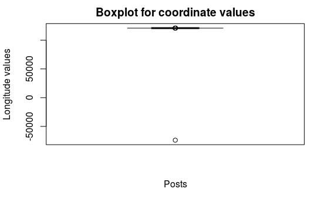

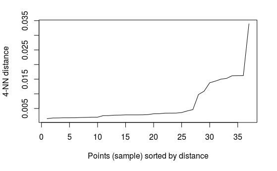

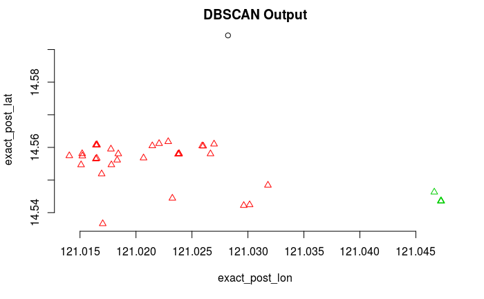

```r
f_acled_results <- f_acled_merge(
  #standard parameters
  p_city_filter = "Manila",p_df = geo_lowy_no_NA,p_eps = 0.015,p_k =4,p_outlier_remove = TRUE,
  #acled parameters
  p_acled_year = 2019,
  p_acled_city = FALSE)
```

```r
f_acled_results$f_map
```

[interactive chart not shown]

### 5.0 Test different cities

Back to index

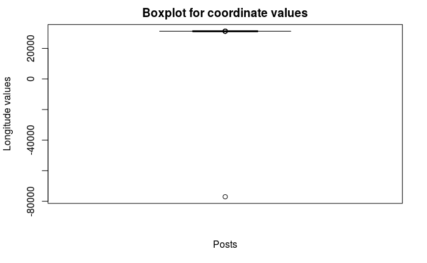

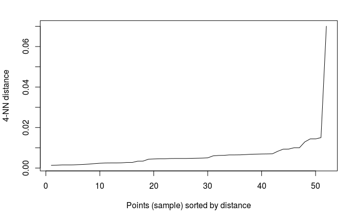

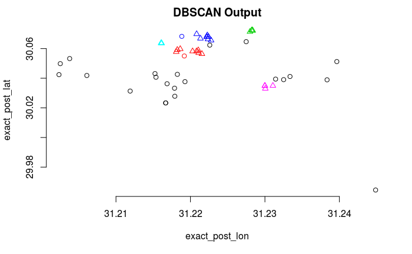

```r
###CAIRO

cairo_results <- f_acled_merge(
  #standard parameters
  p_city_filter = "Cairo",p_df = geo_lowy_no_NA,p_eps = 0.003,p_k =4,p_outlier_remove = TRUE,
  #acled parameters
  p_acled_year = 2019,
  p_acled_city = TRUE)
```

```r
cairo_results$f_map
```

[interactive chart not shown]

```r
NA
```

#### REFERENCE CODE FUNCTIONS

Back to index

**`f_exact_city_postings()`**:

```
###FUNCTION REFERENCE FOR CODE
###FUNCTION
f_exact_city_postings <- function(p_city_filter,p_df){

  ###Subset of dataframe for chosen country
  sub_city_df <- p_df[p_df$post_city == p_city_filter,]

  #create spatial objects
  sub_city_sf <-
    st_as_sf(sub_city_df,coords=c("post_city_lon","post_city_lat"),crs = 4326)

  sub_city_geo_sf <-
    st_as_sf(sub_city_df,coords=c("exact_post_lon","exact_post_lat"),crs = 4326)

  #City lat longs
  exact_map <- mapview(
      #spatial object
      sub_city_sf,
      legend = FALSE,
      layer.name = "City coordinates",
      alpha.regions = 0.4,
      label = sub_city_sf$post_city_country,
      cex = 10

      #Exact lat longs
      )+ mapview(
      #spatial object
      sub_city_geo_sf,
      legend = FALSE,
      layer.name = "Geocoded exact coordinates",
      label = sub_city_geo_sf$full_geo_query,
      color = "red",
      alpha.regions = 0.4,
      col.regions = "red",
      cex = 0.1)

  mapshot(exact_map, url = paste("/cloud/project/Data/MapFiles/",p_city_filter,"map.html",sep="_"))

  #return dl table,map
  return_list <- list(df = sub_city_df,map = exact_map)
  return(return_list)
}
```

Calculate global population and global economy proportions for this dataset.

```r
lowy_meta_df <- read_csv("./Data/Processing/Part_1_Out_Lowy_Meta.csv")
#ECONOMY
economy_summary <- distinct(lowy_meta_df,send_country,meta_gdp_usd_billions)
economy_summary_sum <- sum(economy_summary$meta_gdp_usd_billions)
economy_2019 <- 85.91*1000
economy_coverage <- economy_summary_sum/economy_2019

###POPULATION
people_summary <- distinct(lowy_meta_df,send_country,meta_population_millions)
people_summary_sum <- sum(people_summary$meta_population_millions)
people_2019 <- 7.594*1000
people_coverage <- people_summary_sum/people_2019

cat("Coverage of the world economy is:",economy_coverage*100,"%","\nCoverage of global population is:",people_coverage*100,"%")
```

```
Coverage of the world economy is: 91.78675 %
Coverage of global population is: 74.7577 %
```

```r
#economy from: https://data.worldbank.org/indicator/ny.gdp.mktp.cd
#people from: https://data.worldbank.org/indicator/sp.pop.totl
#85.91 GDP in current dollars in thousands of billions for 2018
#7.594thousand million population in the world in 2018
```

[output not shown]